# Week 6 Lab

(add your name)

2/13, 2/14/2023

#### Task 1: Set up

- Define your chunk options
- Load the libraries that will be frequently used throughout this file

```r
pacman::p_load(haven, tidyverse, modelsummary, flextable, data.table)
```

- Read in the datasets
- Clean the dataset and prepare for analysis

```r
df <- df0 %>%
  select(id = Study_ID, y = BMI, x = EDEQ_restraint, v1 = OE_frequency, v2 = EDS_total, v3 = age_year, v4 = income_group) %>%
  mutate(v2 = ifelse(v2 == -99, NA, v2),
         v4 = as.numeric(as.character(v4))) %>%
  drop_na()
```

- Summary statistics of our sample dataset

```r
df1 <- df %>%
  select(-id) %>%
  rename(BMI = y,
         EDEQ = x,
         BOE = v1,
         EDS = v2,
         Age = v3,
         Income = v4)

datasummary_skim(df1)
```

Unique (#)

Missing (%)

Mean

SD

Min

Median

Max

BMI

580

0

25.4

6.2

7.9

24.3

57.2

EDEQ

31

0

1.4

1.3

0.0

1.2

6.0

BOE

24

0

2.3

3.7

0.0

1.0

29.0

[figure not shown]

EDS

94

0

55.0

24.2

21.0

55.0

126.0

Age

13

0

24.2

3.6

18.0

24.0

30.0

Income

11

0

4.2

3.0

1.0

3.0

11.0

#### Task 2: Summarize the bivariate relationship between BMI and Directory restraint index (EDEQ_restraint)

- Visualize the bivariate relationship

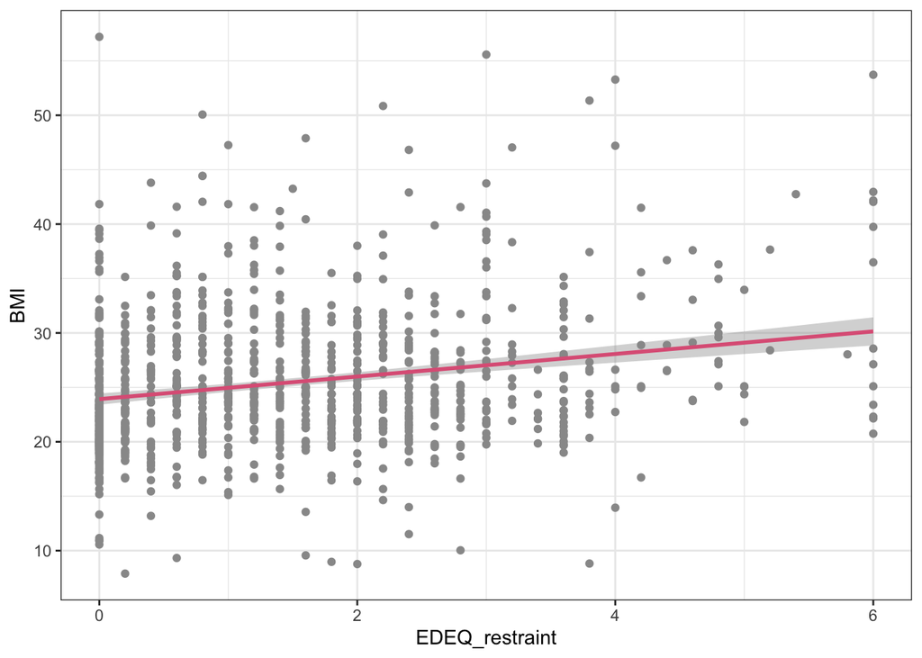

```r
ggplot(df, aes(x, y)) +
  geom_point(color = "grey60") +
  geom_smooth(method = "lm", color = "#de6386") +
  labs( y = "BMI",
        x = "EDEQ_restraint") +
  theme_bw()
```

- Null hypothesis for the relationship between BMI and Directory restraint index

There is no relationship between BMI and Directory restraint index, on average, in the population of research interest.

- Write a formal linear model that describes the simple, bivariate relationship

$$BMI = \beta_0 + \beta_1 * EDEQ +
\epsilon$$

- Using an OLS estimator to estimate this bivariate relationship and report your regression results in a table

```r
m1 <- lm(y ~ x, df)
modelsummary(m1,
             output = 'flextable',
             stars = TRUE,
             gof_omit = "Adj.|Log.Lik.|AIC|BIC",
             coef_rename = c('x' = 'Dietary restraint')) %>%
  autofit()
```

|  | Model 1 |
| --- | --- |
| (Intercept) | 23.922*** |
|  | (0.265) |
| Dietary restraint | 1.037*** |
|  | (0.137) |
| Num.Obs. | 1085 |
| R2 | 0.050 |
| F | 57.250 |
| RMSE | 6.08 |

+ p < 0.1, * p < 0.05, ** p < 0.01, *** p < 0.001

#### Task 3: Produce a correlation matrix and heatmap to assess for potential multicollinearity

- Correlation matrix

```r
datasummary_correlation(df1,
                        fmt = 3,
                        notes = "Notes: cells report Pearson correlation coefficients.")
```

|  | BMI | EDEQ | BOE | EDS | Age | Income |
| --- | --- | --- | --- | --- | --- | --- |
| BMI | 1 | . | . | . | . | . |
| EDEQ | .224 | 1 | . | . | . | . |
| BOE | .084 | .308 | 1 | . | . | . |
| EDS | −.006 | .358 | .198 | 1 | . | . |
| Age | .131 | .030 | .012 | .047 | 1 | . |
| Income | −.041 | .144 | .071 | .117 | .139 | 1 |

Notes: cells report Pearson correlation coefficients.

- Easy correlation heatmap

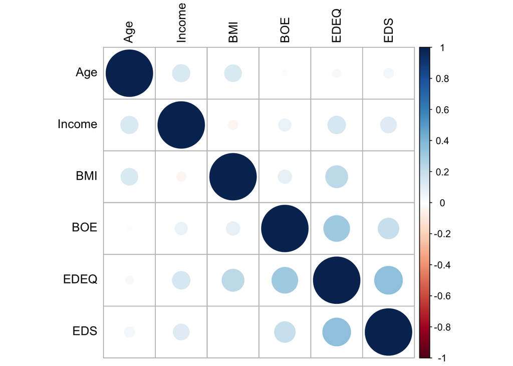

```r
cor <- round(cor(df1), 3)

cor %>%
  corrplot::corrplot(tl.col = "black", order = "hclust", hclust.method = "average")
```

- Fancier correlation heatmap

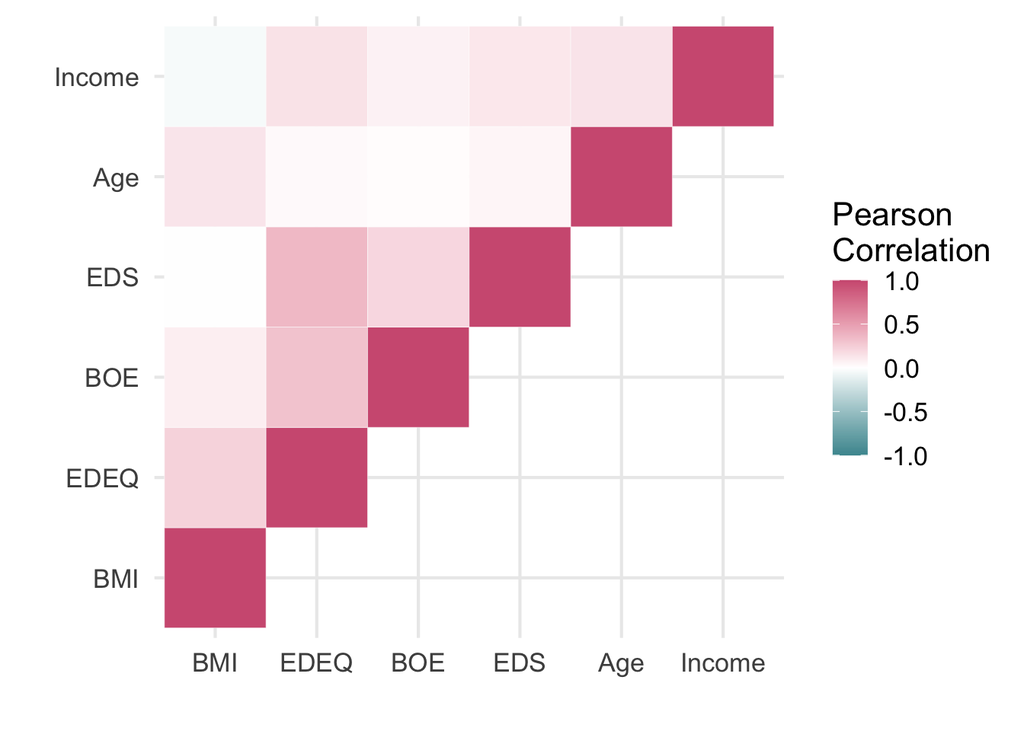

```r
cor[upper.tri(cor)] <- NA

reshape2::melt(cor, na.rm = TRUE) %>%
  ggplot(aes(Var2, Var1, fill = value)) +
  geom_tile(color = "white") +
  scale_fill_gradient2(low = "#4a969e", high = "#d15e81", mid = "white",
                       midpoint = 0, limit = c(-1,1), space = "Lab",
                       name="Pearson\nCorrelation") +
  labs(x = "", y = "") +
  theme_minimal(base_size = 16)
```

#### Task 4: Add one covariate and see if relationship between BMI and Directory restraint index (EDEQ_restraint) changes

- Noticing from task 3 that the correlation coefficients between the predictor (EDEQ) and potential candidates for covariates are all far below 0.8, moreover, among all candidates, **age** has the largest Pearson correlation coefficient with BMI and more importantly, it has the smallest correlation with the predictor variable, so here we add **age** to the model as a covariate.
- Note that the null hypothesis for the relationship between BMI and Directory restraint index is slightly changed

After accounting for age, there is no relationship between BMI and Directory restraint index, on average, in the population of research interest

- Write a formal multiple regression model

$$BMI = \beta_0 + \beta_1 * EDEQ +
\beta_2 * AGE + \epsilon$$

Note here $\beta_1$ is still our coefficient of interest.

- Add the covariate, age, to the previous estimator, and report the results of your estimator together with those of the previous estimator

```r
m2 <- lm(y ~ x + v3, df)
modelsummary(list (m1, m2),
             output = 'flextable',
             stars = TRUE,
             gof_omit = "Adj.|Log.Lik.|AIC|BIC",
             coef_rename = c('x' = 'Dietary restraint',
                             'v3' = 'Age')) %>%
  autofit()
```

|  | Model 1 | Model 2 |
| --- | --- | --- |
| (Intercept) | 23.922*** | 18.691*** |
|  | (0.265) | (1.267) |
| Dietary restraint | 1.037*** | 1.020*** |
|  | (0.137) | (0.136) |
| Age |  | 0.218*** |
|  |  | (0.052) |
| Num.Obs. | 1085 | 1085 |
| R2 | 0.050 | 0.066 |
| F | 57.250 | 37.976 |
| RMSE | 6.08 | 6.03 |

+ p < 0.1, * p < 0.05, ** p < 0.01, *** p < 0.001

Tips: refer to [the lecture slide](https://daviddliebowitz.github.io/EDUC643_23W/slides/EDUC643_7_mult_regression.html#92) and the slides following to see, in the table, where to look for evidence of multicollinearity/collider bias and whether this bias exists.

- Define the prototypical values of covariate, age, as 18, 23, and 28 (you can explore other scenarios), then plot the multivariate-adjusted relationship between BMI and Directory restraint

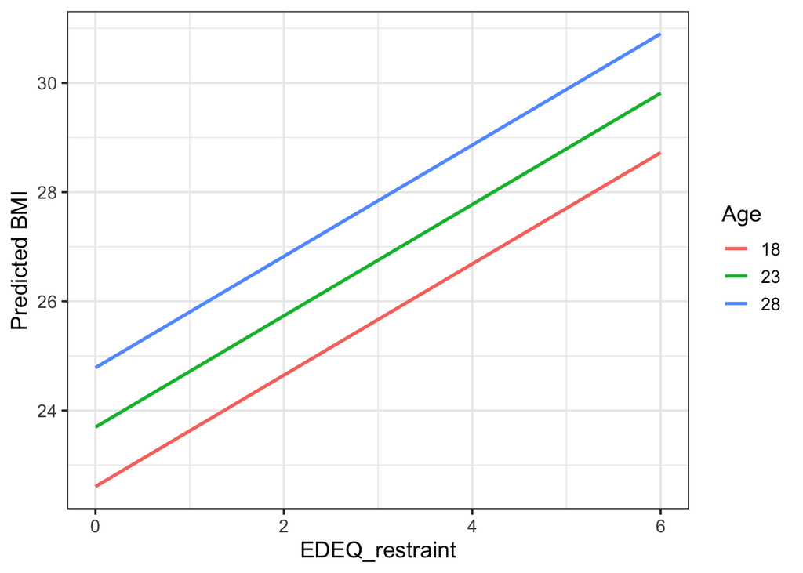

```r
margins::margins(m2, at = list(v3 = c(18, 23, 28))) %>%
  ggplot(aes(x, fitted, color = as.factor(v3))) +
  geom_smooth(method = 'lm', se = F) +
  labs( y = "Predicted BMI",
        x = "EDEQ_restraint",
        color = "Age") +
  scale_color_discrete(name = "Age",
                       breaks=c(18, 23, 28)) +
  theme_bw(base_size = 14)
```

- Alternatively, you can create prototypical plot by hand with a little help from excel. The excel spreadsheet used in the class is available on [course website](https://daviddliebowitz.github.io/EDUC643_23W/schedule.html).
- Always refer to the lecture code or discuss with your GEs in the lab if you have further questions.

Extra:

```r
m3 <- lm(y ~ x + v3 + v2, df)
modelsummary(list (m1, m2, m3),
             output = 'flextable',
             stars = TRUE,
             gof_omit = "Adj.|Log.Lik.|AIC|BIC",
             coef_rename = c('x' = 'Dietary restraint',
                             'v3' = 'Age')) %>%
  autofit()
```

|  | Model 1 | Model 2 | Model 3 |
| --- | --- | --- | --- |
| (Intercept) | 23.922*** | 18.691*** | 19.775*** |
|  | (0.265) | (1.267) | (1.303) |
| Dietary restraint | 1.037*** | 1.020*** | 1.192*** |
|  | (0.137) | (0.136) | (0.145) |
| Age |  | 0.218*** | 0.224*** |
|  |  | (0.052) | (0.051) |
| v2 |  |  | -0.027*** |
|  |  |  | (0.008) |
| Num.Obs. | 1085 | 1085 | 1085 |
| R2 | 0.050 | 0.066 | 0.075 |
| F | 57.250 | 37.976 | 29.243 |
| RMSE | 6.08 | 6.03 | 6.00 |

+ p < 0.1, * p < 0.05, ** p < 0.01, *** p < 0.001

```r
range(df$v2)
```

```
## [1]  21 126
```

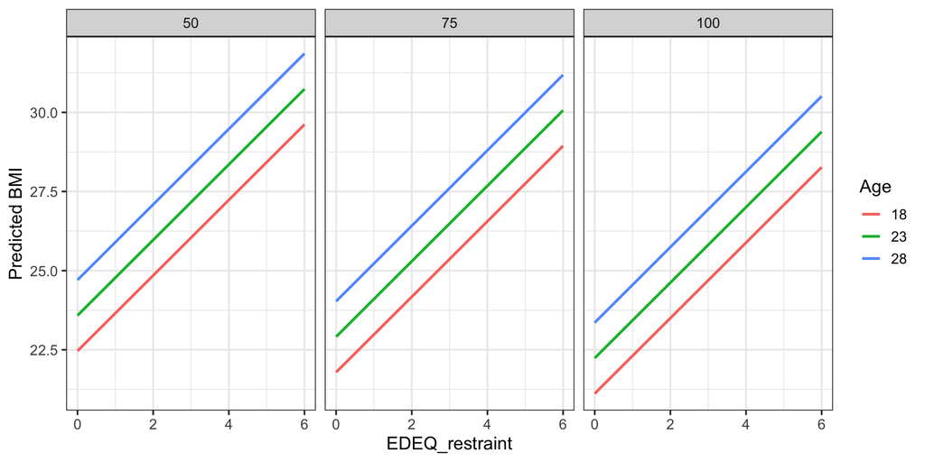

```r
margins::margins(m3, at = list(v3 = c(18, 23, 28), v2 = c(50, 75, 100))) %>%
  ggplot(aes(x, fitted, color = as.factor(v3))) +
  geom_smooth(method = 'lm', se = F) +
  labs( y = "Predicted BMI",
        x = "EDEQ_restraint",
        color = "Age") +
  scale_color_discrete(name = "Age",
                       breaks=c(18, 23, 28)) +
  facet_wrap(~ as.factor(v2)) +
  theme_bw(base_size = 14)
```

[^1]: Noticing in the lab that some of you are still misplacing y (outcome variable) and x (predictor variable) then get overwhelmed by bug messages, from this lab going forward, I will explicitly use the notations of **x (predictor variable), y (outcome variable), v1 (covariate 1), v2 (covariate 2), …vz(covariate z)** in my code instead of variable names, so you’ll be clear about the arguments of a function, like lm(**y ~ x**, data) and ggplot(data, aes(**x, y**)). Note that you don’t have to do this in your code if you’re confident about the function usage - I do not do this in my research. This is just for pedagogical purposes.